# Assignment3

##### 3.1>

```r
library(alr4)
head(UBSprices)
```

```
##           bigmac2009 bread2009 rice2009 bigmac2003 bread2003 rice2003
## Amsterdam         19        10       11         16         9        9
## Athens            30        13       27         21        12       19
## Auckland          19        19       13         19        19        9
## Bangkok           45        43       27         50        42       25
## Barcelona         21        17        8         22        19       10
## Berlin            19        10       17         16        10       16
```

```r
plot(x = UBSprices$bigmac2003,y = UBSprices$bigmac2009,xlim = c(0,140),ylim = c(0,140),main = "Green - y=x | Red - Fit")
abline(a=0,b=1,col="green")
fit <- lm(data = UBSprices, formula = bigmac2009~bigmac2003)
beta0 <- summary(fit)$coefficients[1,1]
beta1 <- summary(fit)$coefficients[2,1]
#abline(a=beta0,b=beta1)
#lines(UBSprices$bigmac2003,fitted(res))
summary(fit)
```

```
##
## Call:
## lm(formula = bigmac2009 ~ bigmac2003, data = UBSprices)
##
## Residuals:
##     Min      1Q  Median      3Q     Max
## -32.968  -5.258  -2.159   0.187  77.081
##
## Coefficients:
##             Estimate Std. Error t value Pr(>|t|)
## (Intercept)  6.73612    3.84985   1.750   0.0861 .
## bigmac2003   0.77886    0.07975   9.767 2.33e-13 ***
## ---
## Signif. codes:  0 '***' 0.001 '**' 0.01 '*' 0.05 '.' 0.1 ' ' 1
##
## Residual standard error: 18.35 on 52 degrees of freedom
## Multiple R-squared:  0.6472, Adjusted R-squared:  0.6404
## F-statistic: 95.39 on 1 and 52 DF,  p-value: 2.334e-13
```

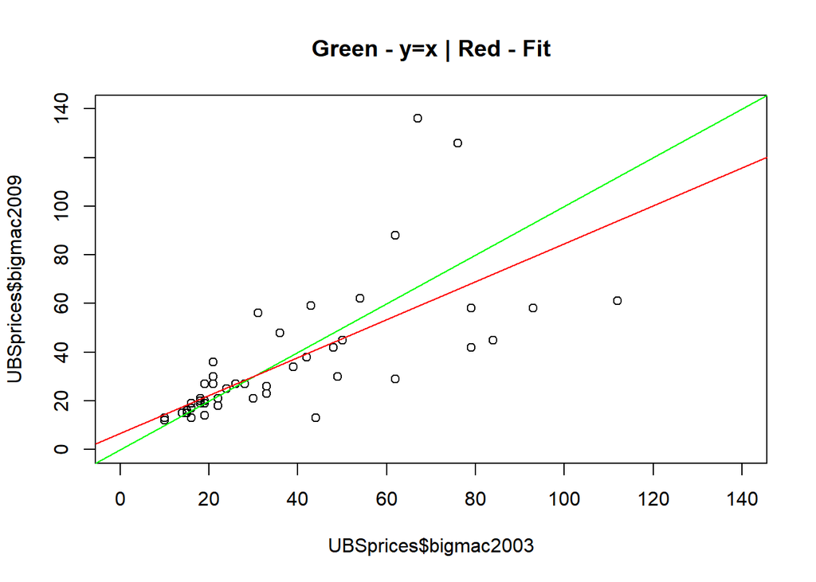

```r
abline(fit,col="red")
```

##### Unusual Observations

1. Our Linear Estimation curve doesn’t seem like going through the mean near the cluster around X=20.  
That is probably due to the point at around X=110  
2. Variance of Y foreach X doesn’t seem to be same. That is expected because X and Y, doesn’t seem to follow bivariate normal distributions.

- From the figure, we can easily see that Y doesn’t follow a linear relationship with X when X>=60
- Again from the figure, we can see that variance of Y is very high while we move along X. So for each fixed X, E(Y|X) doesn’t seem to have a fixed variance.

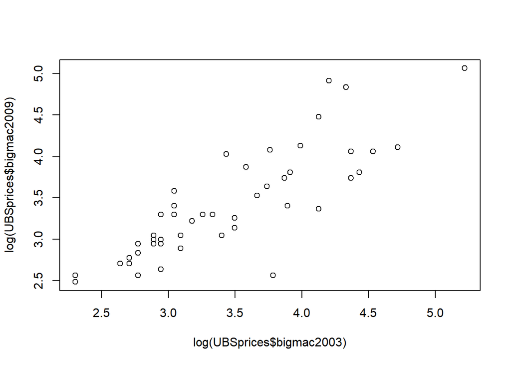

```r
plot(x = log(UBSprices$bigmac2003),y = log(UBSprices$bigmac2009))
```

After log transform we can see that the points in log scale seem to have a linear realtionship. And variance have clearly decreased.